# SuministrosMIPRES

Antonio Romero

11/4/2020

El Sistema General de Seguridad Social en Salud cuenta con mecanismos de financiación para garantizar el acceso y la prestación de servicios y tecnologías en salud. El principal mecanismo de financiación es la Unidad de Pago por Capitación o UPC, la cual constituye la prima mensual que es asignada a cada una de las Entidades Promotoras de Salud para la cobertura de el Plan Básico de Salud o PBS, este inluye el listado de servicios a los cuales tiene acceso un paciente.

En el caso de que un paciente requiera acceder a un servicio o tecnología no incluido en el PBS y no financiado con cargo a la UPS, la EPS junto con la Institución Prestadora de Servicios de Salud - IPS, deberá hacer uso de una herramienta tecnológica denominada MIPRES que permite a los profesionales de salud reportar la prescripción de tecnologías en salud o servicios complementarios no financiados con recursos de la UPC.

Vale la pena indicar, que se encuentra registro desde la primera entrega hasta la entrega 108 de medicamentos, con lo cual se hace necesario determinar las diferencias entre las entregas consecutivas para determinar si existe algún comportamiento entre las mismas.

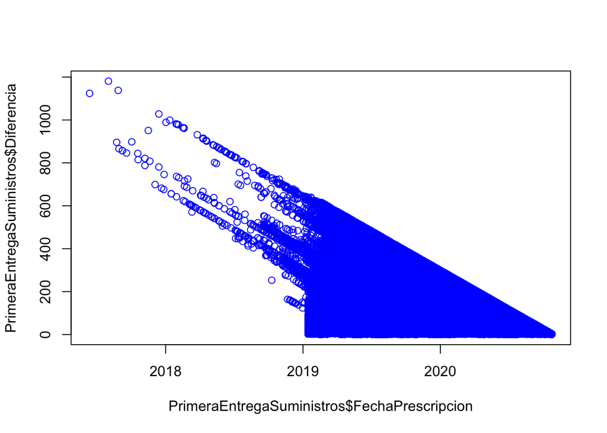

```
## # Source: spark<?> [?? x 1]
##   Promedio_entrega
##              <dbl>
## 1             90.0
```

```r
knitr::opts_chunk$set(echo = FALSE)
plot(PrimeraEntregaSuministros$FechaPrescripcion, PrimeraEntregaSuministros$Diferencia, type="p", col="blue")
```

Teniendo en cuenta sólo los tiempos de suministro de la primera entrega de los medicamentos, se calculó el tiempo promedio transcurrido entre la fecha de prescripción y el suministro del medicamento para cada mes. A continuación se evidencia el comportamiento para las fechas de entrega del año 2020.

## Including Plots

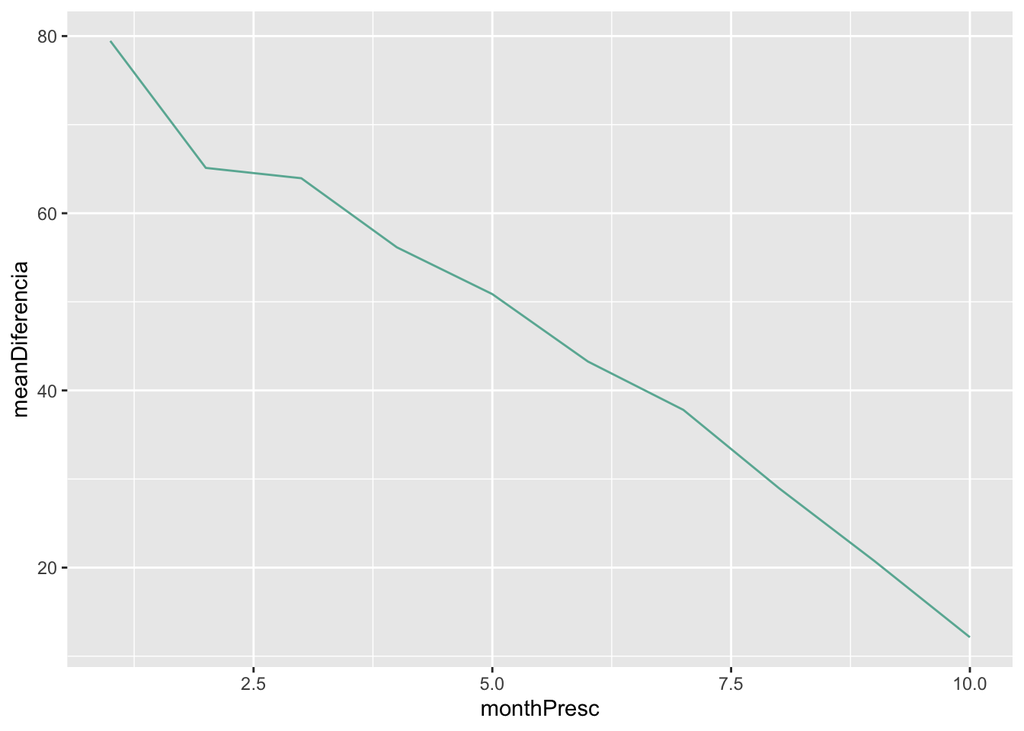

```
## # Source:     spark<?> [?? x 5]
## # Ordered by: desc(meanDiferencia)
##    CodEPS meanDiferencia maxDiferencia minDiferencia numPresc
##    <chr>           <dbl>         <dbl>         <dbl>    <dbl>
##  1 EPSIC6           312.           433           127       17
##  2 CCFC23           276.           374            85        9
##  3 CCFC33           259            259           259        1
##  4 CCF033           249.           318           101       43
##  5 EPSI06           247.           469            76      218
##  6 EPS023           241            321           201        2
##  7 EPS046           239.           660            32     1428
##  8 ESSC33           238.           562            13      513
##  9 CCF007           236.           367            81      116
## 10 CCFC55           224.           896            13      655
## # … with more rows
```

```
## # Source:     spark<?> [?? x 5]
## # Ordered by: meanDiferencia
##    CodDxPpal meanDiferencia maxDiferencia minDiferencia numPresc
##    <chr>              <dbl>         <dbl>         <dbl>    <dbl>
##  1 J060                   2             2             2        1
##  2 X611                   2             2             2        1
##  3 Z122                   3             3             3        1
##  4 T431                   3             3             3        1
##  5 T754                   3             3             3        1
##  6 P392                   3             3             3        1
##  7 A561                   3             3             3        1
##  8 C792                   3             3             3        1
##  9 O821                   3             3             3        1
## 10 O721                   3             3             3        1
## # … with more rows
```

```
## # Source:     spark<?> [?? x 5]
## # Ordered by: desc(meanDiferencia)
##    nombre              meanDiferencia maxDiferencia minDiferencia numPresc
##    <chr>                        <dbl>         <dbl>         <dbl>    <dbl>
##  1 Zambrano                      372.           468           267        9
##  2 Aracataca                     356.           477            36       16
##  3 Mitú                          284.           425            28        8
##  4 Oiba                          280.           522            27       62
##  5 Chima                         271.           519            77        5
##  6 Ortega                        269            354           160        4
##  7 Surata                        255.           401             5       22
##  8 Labateca                      245.           452            52       15
##  9 San José De Miranda           238.           369            24        3
## 10 Valle Del Guamuez             232.           419            46        2
## # … with more rows
```